# Parametric Survival Analysis

## 3.9 Model Adequacy for Weibull Distribution

Weibull model is fit if the groups’ lines are parallel and linear (not flat)

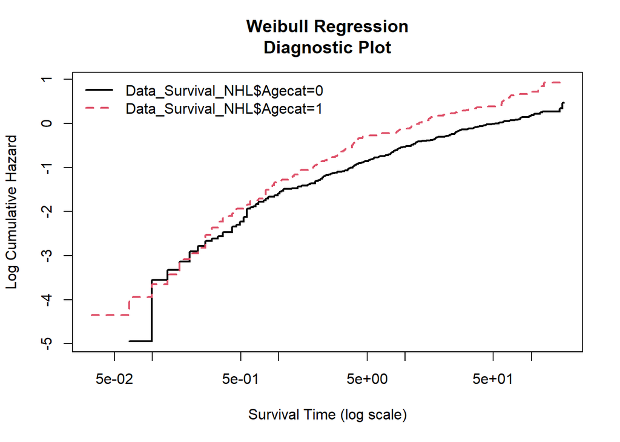

```r
WeibullDiag(Surv(time = Data_Survival_NHL$duration_i_month, event = Data_Survival_NHL$`Alive:0_Death:1` == 1) ~ Data_Survival_NHL$Agecat,
            data = Data_Survival_NHL)
```

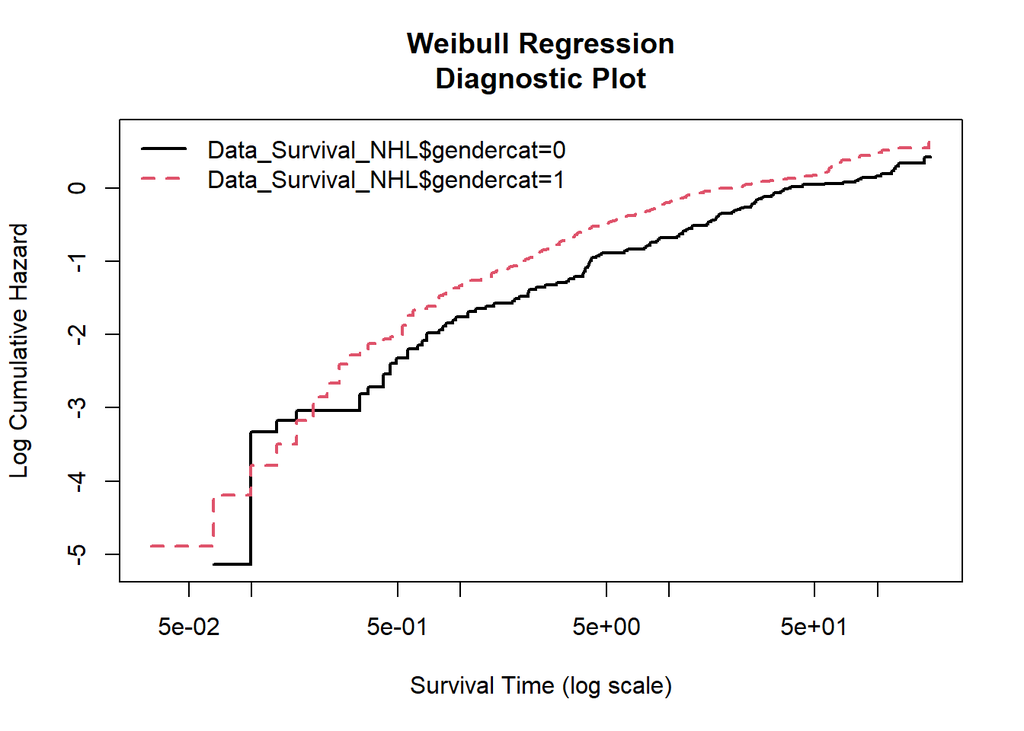

```r
WeibullDiag(Surv(time = Data_Survival_NHL$duration_i_month, event = Data_Survival_NHL$`Alive:0_Death:1` == 1) ~ Data_Survival_NHL$gendercat,
            data = Data_Survival_NHL)
```

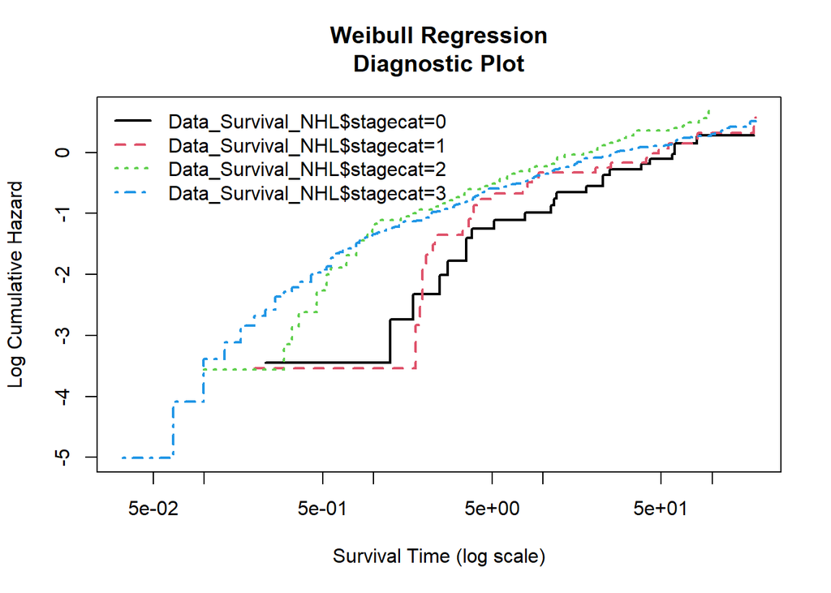

```r
WeibullDiag(Surv(time = Data_Survival_NHL$duration_i_month, event = Data_Survival_NHL$`Alive:0_Death:1` == 1) ~ Data_Survival_NHL$stagecat,
            data = Data_Survival_NHL)
```

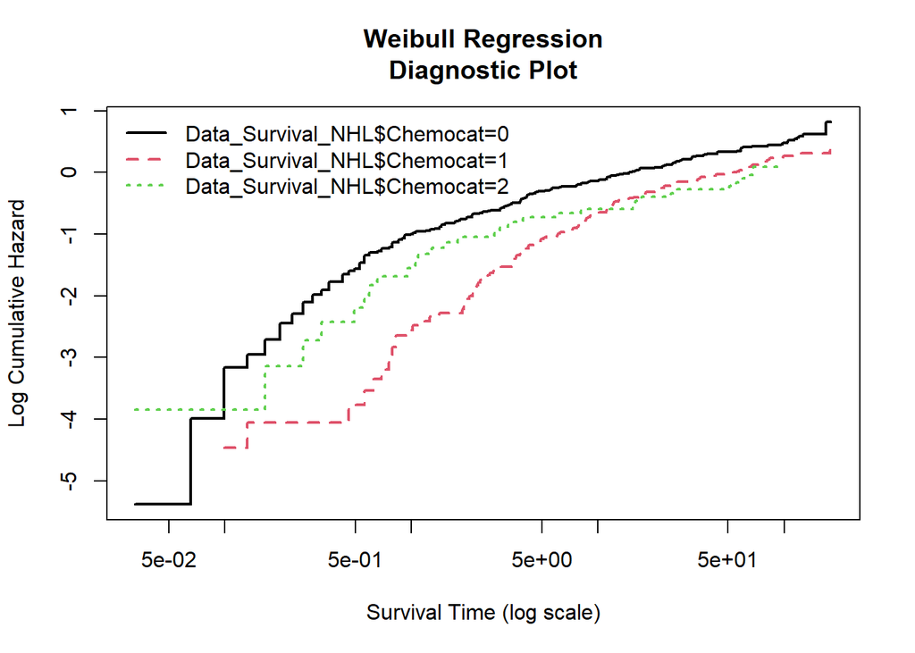

```r
WeibullDiag(Surv(time = Data_Survival_NHL$duration_i_month, event = Data_Survival_NHL$`Alive:0_Death:1` == 1) ~ Data_Survival_NHL$Chemocat,
            data = Data_Survival_NHL)
```

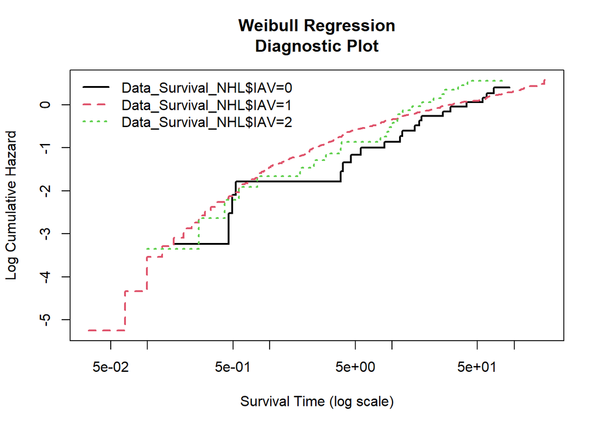

```r
WeibullDiag(Surv(time = Data_Survival_NHL$duration_i_month, event = Data_Survival_NHL$`Alive:0_Death:1` == 1) ~ Data_Survival_NHL$IAV,
            data = Data_Survival_NHL)
```

## 3.10 Checking Assumption

```r
kmfit <- survfit(surv.mod ~ Data_Survival_NHL$Agecat + Data_Survival_NHL$gendercat + Data_Survival_NHL$Chemocat + Data_Survival_NHL$stagecat + Data_Survival_NHL$IAV )
summary(kmfit)
```

```
Call: survfit(formula = surv.mod ~ Data_Survival_NHL$Agecat + Data_Survival_NHL$gendercat +
    Data_Survival_NHL$Chemocat + Data_Survival_NHL$stagecat +
    Data_Survival_NHL$IAV)

                Data_Survival_NHL$Agecat=0, Data_Survival_NHL$gendercat=0, Data_Survival_NHL$Chemocat=0, Data_Survival_NHL$stagecat=0, Data_Survival_NHL$IAV=0
        time       n.risk      n.event     survival      std.err lower 95% CI
        11.7          1.0          1.0          0.0          NaN           NA
upper 95% CI
          NA

                Data_Survival_NHL$Agecat=0, Data_Survival_NHL$gendercat=0, Data_Survival_NHL$Chemocat=0, Data_Survival_NHL$stagecat=0, Data_Survival_NHL$IAV=1
        time       n.risk      n.event     survival      std.err lower 95% CI
        38.1          1.0          1.0          0.0          NaN           NA
upper 95% CI
          NA

                Data_Survival_NHL$Agecat=0, Data_Survival_NHL$gendercat=0, Data_Survival_NHL$Chemocat=0, Data_Survival_NHL$stagecat=1, Data_Survival_NHL$IAV=1
  time n.risk n.event survival std.err lower 95% CI upper 95% CI
  7.59      3       1    0.667   0.272       0.2995            1
 43.43      2       1    0.333   0.272       0.0673            1

                Data_Survival_NHL$Agecat=0, Data_Survival_NHL$gendercat=0, Data_Survival_NHL$Chemocat=0, Data_Survival_NHL$stagecat=2, Data_Survival_NHL$IAV=1
    time n.risk n.event survival std.err lower 95% CI upper 95% CI
  0.0986      4       1     0.75   0.217       0.4259            1
  0.3288      3       1     0.50   0.250       0.1877            1
  0.6904      2       1     0.25   0.217       0.0458            1
 27.5507      1       1     0.00     NaN           NA           NA

                Data_Survival_NHL$Agecat=0, Data_Survival_NHL$gendercat=0, Data_Survival_NHL$Chemocat=0, Data_Survival_NHL$stagecat=3, Data_Survival_NHL$IAV=0
        time       n.risk      n.event     survival      std.err lower 95% CI
       0.493        1.000        1.000        0.000          NaN           NA
upper 95% CI
          NA

                Data_Survival_NHL$Agecat=0, Data_Survival_NHL$gendercat=0, Data_Survival_NHL$Chemocat=0, Data_Survival_NHL$stagecat=3, Data_Survival_NHL$IAV=1
     time n.risk n.event survival std.err lower 95% CI upper 95% CI
   0.0658     36       1    0.972  0.0274       0.9200        1.000
   0.0986     35       3    0.889  0.0524       0.7919        0.998
   0.4274     32       1    0.861  0.0576       0.7552        0.982
   0.4603     31       1    0.833  0.0621       0.7201        0.964
```

[output cut: 514 more lines]

```
        1.05         1.00         1.00         0.00          NaN           NA
upper 95% CI
          NA

                Data_Survival_NHL$Agecat=1, Data_Survival_NHL$gendercat=1, Data_Survival_NHL$Chemocat=2, Data_Survival_NHL$stagecat=3, Data_Survival_NHL$IAV=1
    time n.risk n.event survival std.err lower 95% CI upper 95% CI
  0.0329     13       1    0.923  0.0739        0.789        1.000
  0.5918     12       1    0.846  0.1001        0.671        1.000
  1.2822     11       1    0.769  0.1169        0.571        1.000
  1.4795     10       1    0.692  0.1280        0.482        0.995
  2.7945      9       1    0.615  0.1349        0.400        0.946
  2.9918      8       1    0.538  0.1383        0.326        0.891
  6.0493      7       1    0.462  0.1383        0.257        0.830
 57.8301      6       1    0.385  0.1349        0.193        0.765
 60.8877      4       1    0.288  0.1311        0.118        0.703
```

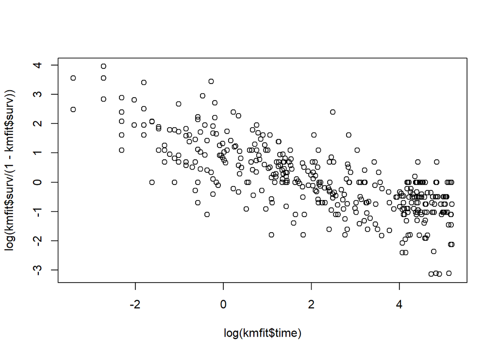

```r
plot(log(kmfit$time), log(kmfit$surv/(1-kmfit$surv)))
```

# 4 Model Comparison

### 4.0.1 Model comparison between Cox PH and WeibullPH

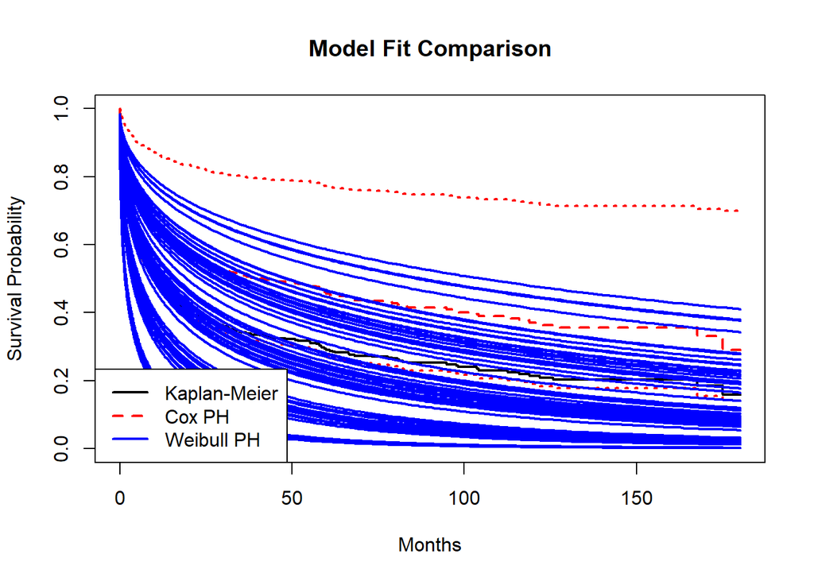

```r
km <- survfit(Surv(duration_i_month, `Alive:0_Death:1`) ~ 1, data = Data_Survival_NHL)
plot(km, conf.int = FALSE, lwd = 2, col = "black", xlab = "Months", ylab = "Survival Probability",
     main = "Model Fit Comparison", xlim = c(0, max(Data_Survival_NHL$duration_i_month)))

cox.mod <- coxph(Surv(duration_i_month, `Alive:0_Death:1`) ~
                   Agecat + stagecat + gendercat + Chemocat + IAV,
                 data = Data_Survival_NHL)
cox.pred <- survfit(cox.mod)
lines(cox.pred, col = "red", lwd = 2, lty = 2)

library(flexsurv)
weib.mod <- flexsurvreg(Surv(duration_i_month, `Alive:0_Death:1`) ~
                          Agecat + stagecat + gendercat + Chemocat + IAV,
                        data = Data_Survival_NHL, dist = "weibullPH")
lines(weib.mod, col = "blue", lwd = 2, ci = FALSE)

legend("bottomleft",
       legend = c("Kaplan-Meier", "Cox PH", "Weibull PH"),
       col = c("black", "red", "blue"),
       lty = c(1, 2, 1),
       lwd = 2)
```

### 4.0.2 Interpretation

##AIC Comparison

```r
exp.mod_AIC <- AIC(exp.mod)
wei.mod.aft_AIC <- AIC(wei.mod.aft)
wei.mod.ph_AIC <- AIC(wei.mod.ph)
log.logistic.mod_AIC <- AIC(log.logistic.mod)
```

```r
aic_values <- data.frame(
  Model = c("Weibull AFT", "Weibull PH", "Exponential", "Log-Logistic"),
  AIC = c(wei.mod.aft_AIC, wei.mod.ph_AIC, exp.mod_AIC, log.logistic.mod_AIC)
)

print(aic_values)
```

```
         Model      AIC
1  Weibull AFT 2793.212
2   Weibull PH 2793.212
3  Exponential 3198.215
4 Log-Logistic 2755.012
```

### 4.0.3 Interpretation

Although the log-logistic model had the lowest AIC, the Weibull model was chosen for its clinical relevance and interpretability. It supports both AFT and PH frameworks and assumes a monotonic hazard, which aligns better with the disease’s progression. Additionally, the Weibull model is widely used in literature and showed a good visual fit to the observed survival data.

The final model are the Weibull model, the package survreg able to describe AFT only, for PH, the package flexsurvreg is better which is for both AFT and PH